# Time course RNA-seq with maSigPro

Tutorial

Damir Baranasic

01/12/2017

# 1 Load required packages

Before we start the analysis, we will first load all the packages needed.

```r
library("DESeq2")
```

```r
library("maSigPro")
library("ggplot2")
library("dplyr")
library("plyr")
library("org.Dr.eg.db")
library("clusterProfiler")
```

# 2 Data preparation

We need to prepare the data for the analysis (Etard et al. 2015). This includes reading the counts for each sample and making the matrix with sample description.

## 2.1 Make a list of files

```r
seq_ids = c("DCD001548SQ", "DCD001559SQ", "DCD001546SQ", "DCD001558SQ", "DCD001547SQ",
    "DCD001545SQ", "DCD001560SQ", "DCD001554SQ", "DCD001564SQ", "DCD001555SQ",
    "DCD001565SQ", "DCD001551SQ")
files = sapply(seq_ids, function(x) paste("data/RNA-seq_Strahle_Lab_0005AS.",
    x, ".USERvgourain.R.ReadsPerGene.out.tab", sep = ""), USE.NAMES = FALSE)
head(files)
```

```
## [1] "data/RNA-seq_Strahle_Lab_0005AS.DCD001548SQ.USERvgourain.R.ReadsPerGene.out.tab"
## [2] "data/RNA-seq_Strahle_Lab_0005AS.DCD001559SQ.USERvgourain.R.ReadsPerGene.out.tab"
## [3] "data/RNA-seq_Strahle_Lab_0005AS.DCD001546SQ.USERvgourain.R.ReadsPerGene.out.tab"
## [4] "data/RNA-seq_Strahle_Lab_0005AS.DCD001558SQ.USERvgourain.R.ReadsPerGene.out.tab"
## [5] "data/RNA-seq_Strahle_Lab_0005AS.DCD001547SQ.USERvgourain.R.ReadsPerGene.out.tab"
## [6] "data/RNA-seq_Strahle_Lab_0005AS.DCD001545SQ.USERvgourain.R.ReadsPerGene.out.tab"
```

Now, when we have created a list of file names, we can make add the sample description to them.

```r
type <- rep(c("wt", "mut"), each = 6)
type
```

```
##  [1] "wt"  "wt"  "wt"  "wt"  "wt"  "wt"  "mut" "mut" "mut" "mut" "mut"
## [12] "mut"
```

```r
repl <- rep(c("1", "2"), times = 6)
repl
```

```
##  [1] "1" "2" "1" "2" "1" "2" "1" "2" "1" "2" "1" "2"
```

```r
time = rep(c("24", "48", "72"), each = 2, times = 2)
time
```

```
##  [1] "24" "24" "48" "48" "72" "72" "24" "24" "48" "48" "72" "72"
```

```r
sample <- Map(function(x, y, z) paste(x, y, z, sep = "_"), type, time, repl)
files <- setNames(files, sample)
head(files)
```

```
##                                                                           wt_24_1
## "data/RNA-seq_Strahle_Lab_0005AS.DCD001548SQ.USERvgourain.R.ReadsPerGene.out.tab"
##                                                                           wt_24_2
## "data/RNA-seq_Strahle_Lab_0005AS.DCD001559SQ.USERvgourain.R.ReadsPerGene.out.tab"
##                                                                           wt_48_1
## "data/RNA-seq_Strahle_Lab_0005AS.DCD001546SQ.USERvgourain.R.ReadsPerGene.out.tab"
##                                                                           wt_48_2
## "data/RNA-seq_Strahle_Lab_0005AS.DCD001558SQ.USERvgourain.R.ReadsPerGene.out.tab"
##                                                                           wt_72_1
## "data/RNA-seq_Strahle_Lab_0005AS.DCD001547SQ.USERvgourain.R.ReadsPerGene.out.tab"
##                                                                           wt_72_2
## "data/RNA-seq_Strahle_Lab_0005AS.DCD001545SQ.USERvgourain.R.ReadsPerGene.out.tab"
```

## 2.2 Read the reads per gene counts

When we have a list of files with the sample description, we will can read the counts from the file.

The files with read counts are formatted in the following manner:

```
N_unmapped  1150343 1150343 1150343
N_multimapping  6528951 6528951 6528951
N_noFeature 5208900 23323138    23435853
N_ambiguous 1011496 219186  215426
ENSDARG00000104632  27  16  14
ENSDARG00000100660  98  51  48
ENSDARG00000098417  48  27  22
ENSDARG00000100422  4445    2184    2280
ENSDARG00000102128  286 141 147
ENSDARG00000103095  1661    802 866
```

The first four lines contain the global mapping statistics. For our purpose, we can just skip them. The counts start on the fifth line. The first column are the gene identifiers, the second represents the total counts per gene, while the third and the fourth column represent the strand specific counts. To facilitate parsing of all twelve files in our case study, we can make a simple helper function, which will read the counts in an R data frame. The function is just a wrap around the `read.csv` function from the `utils` package. It has an argument for naming the columns.

```r
readTagsPerGene <- function(x) {
    out <- read.csv(x, skip = 4, header = FALSE, sep = "\t", row.names = 1,
        col.names = c("", "totalCount", "forwardCount", "reverseCount"))
    out
}
```

Now we can iterate through all the files and extract the counts with `lapply` using the function we just defined.

```r
allReadsCounts <- lapply(files, readTagsPerGene)
head(allReadsCounts[[1]])
```

```
##                    totalCount forwardCount reverseCount
## ENSDARG00000104632        100           57           49
## ENSDARG00000100660        153           78           81
## ENSDARG00000098417         46           29           21
## ENSDARG00000100422       9869         4920         4993
## ENSDARG00000102128        866          451          419
## ENSDARG00000103095       1636          823          822
```

Since the library is unstranded, we only need the total reads count. We can extract it and put it in a matrix. The column names will be the sample names we created previously, and the row names will be the gene identifiers. The gene order is consistent through all the samples, so it is safe, for simplicity sake to take only one to name the matrix.

```r
totalReadsCount <- sapply(allReadsCounts, function(x) x$totalCount)
rownames(totalReadsCount) <- row.names(allReadsCounts[[1]])
head(totalReadsCount)
```

```
##                    wt_24_1 wt_24_2 wt_48_1 wt_48_2 wt_72_1 wt_72_2
## ENSDARG00000104632     100      70      67      30      48      27
## ENSDARG00000100660     153     107     110      81      74      98
## ENSDARG00000098417      46      24      44      37      24      48
## ENSDARG00000100422    9869    6558    5453    3516    3203    4445
## ENSDARG00000102128     866     578     397     233     363     286
## ENSDARG00000103095    1636    1113    1138     660    1524    1661
##                    mut_24_1 mut_24_2 mut_48_1 mut_48_2 mut_72_1 mut_72_2
## ENSDARG00000104632       75       69       44       26       44       54
## ENSDARG00000100660      107      131       72       42      118      167
## ENSDARG00000098417       32       32       63       10       29       41
## ENSDARG00000100422     7348     7749     4836     2406     3513     3922
## ENSDARG00000102128      799      703      462      250      401      405
## ENSDARG00000103095     1266     1285     1146      621     1415     1755
```

## 2.3 Make a matrix with the experimental design

Before the analysis, we need to normalise the data to address for the biases in the library preparation. For data normalisation, we will use the `DESeq2` package. The package also requires an additional matrix which describes the data design. The design matrix has sample names as rows and sample features as columns. The features we will use are already defined in the `time` and `type` vectors.

```r
coldata <- data.frame(condition = type, time = time)
row.names(coldata) <- sample
head(coldata)
```

```
##         condition time
## wt_24_1        wt   24
## wt_24_2        wt   24
## wt_48_1        wt   48
## wt_48_2        wt   48
## wt_72_1        wt   72
## wt_72_2        wt   72
```

# 3 Data normalisation

We will use the package `DESseq2` to normalise the data (Anders and Huber 2010)(Love, Huber, and Anders 2014).

```r
dds <- DESeqDataSetFromMatrix(countData = totalReadsCount, colData = coldata,
    design = ~time + condition)
head(dds)
```

```
## class: DESeqDataSet
## dim: 6 12
## metadata(1): version
## assays(1): counts
## rownames(6): ENSDARG00000104632 ENSDARG00000100660 ...
##   ENSDARG00000102128 ENSDARG00000103095
## rowData names(0):
## colnames(12): wt_24_1 wt_24_2 ... mut_72_1 mut_72_2
## colData names(2): condition time
```

```r
dds <- DESeq(dds)
head(dds)
```

```
## class: DESeqDataSet
## dim: 6 12
## metadata(1): version
## assays(3): counts mu cooks
## rownames(6): ENSDARG00000104632 ENSDARG00000100660 ...
##   ENSDARG00000102128 ENSDARG00000103095
## rowData names(29): baseMean baseVar ... deviance maxCooks
## colnames(12): wt_24_1 wt_24_2 ... mut_72_1 mut_72_2
## colData names(3): condition time sizeFactor
```

```r
normalizedData <- counts(dds, normalized = TRUE)
head(normalizedData)
```

```
##                       wt_24_1    wt_24_2    wt_48_1    wt_48_2    wt_72_1
## ENSDARG00000104632   57.08065   56.05454   73.11288   43.15282   48.56405
## ENSDARG00000100660   87.33339   85.68336  120.03608  116.51263   74.86957
## ENSDARG00000098417   26.25710   19.21870   48.01443   53.22182   24.28202
## ENSDARG00000100422 5633.28892 5251.50941 5950.51563 5057.51101 3240.63835
## ENSDARG00000102128  494.31839  462.85033  433.22111  335.15360  367.26560
## ENSDARG00000103095  933.83936  891.26715 1241.82776  949.36214 1541.90848
##                       wt_72_2   mut_24_1   mut_24_2   mut_48_1   mut_48_2
## ENSDARG00000104632   22.52972   59.92538   52.35225   50.81931   51.31421
## ENSDARG00000100660   81.77453   85.49354   99.39340   83.15888   82.89218
## ENSDARG00000098417   40.05283   25.56816   24.27930   72.76402   19.73623
## ENSDARG00000100422 3709.05921 5871.08876 5879.38509 5585.50460 4748.53774
## ENSDARG00000102128  238.64813  638.40500  533.38595  533.60280  493.40583
## ENSDARG00000103095 1385.99490 1011.54033  974.96578 1323.61213 1225.62009
##                      mut_72_1   mut_72_2
## ENSDARG00000104632   49.84316   51.89721
## ENSDARG00000100660  133.67030  160.49693
## ENSDARG00000098417   32.85118   39.40344
## ENSDARG00000100422 3979.52337 3769.27512
## ENSDARG00000102128  454.25245  389.22907
## ENSDARG00000103095 1602.91078 1686.65932
```

# 4 Differential expression with `maSigPro`

In this step, we will use the `maSigPro` package (Conesa et al. 2006) to model the differential expression of genes (Nueda, Tarazona, and Conesa 2014) in a *unc45b* mutant and control during a course of 48 hours.

## 4.1 Experimental design in `maSigPro` format

`maSigPro` takes a specific matrix format for the experimental design. As with `DESeq2`, `maSigPro` uses the format of samples represented in rows and features in columns. The first two columns are Time and Replicate. Obviously, the Time variable represent the time points of the experiments. The Replicate column represent replicates in a way that samples with the same condition, therefore replicates, share the same number. In our case, we have 3 time points and 2 types (wild type and mutant), so in total 6 different conditions. Each condition has 2 replicates, resulting in 12 samples. The last two columns represent the Control and Mutant, each containing a binary identifier. We will load the example to show how this should look like.

```r
data(edesign.abiotic)
data(data.abiotic)

head(data.abiotic)
```

```
##         Control_3H_1 Control_3H_2 Control_3H_3 Control_9H_1 Control_9H_2
## STMDF90   0.13735714  -0.36530651  -0.15329448   0.44754535  0.287476796
## STMCJ24           NA           NA           NA           NA           NA
## STMJH42   0.07864449   0.10023285  -0.17365488  -0.25279484  0.184855409
## STMDE66   0.22976991   0.47409748   0.46930716   0.37101059 -0.004992029
## STMIX74   0.14407618  -0.48018637  -0.07847999   0.05692331  0.013045420
## STMCL34   0.06494078   0.04472986   0.04280790   0.16128091  0.088048892
##         Control_9H_3 Control_27H_1 Control_27H_2 Control_27H_3  Cold_3H_1
## STMDF90  0.248818724   0.179325865    0.12799310   -0.11734684  1.0565554
## STMCJ24           NA            NA            NA   -0.48580961         NA
## STMJH42 -0.118319967  -0.148218361   -0.09114789   -0.27132618 -0.1697002
## STMDE66  0.002459839  -0.003879953    0.26182764    0.29449032 -1.9084427
## STMIX74  0.076794351  -0.128584206    0.19345354    0.10940092  0.2686839
## STMCL34  0.277007348   0.046143427    0.16275591    0.05627787 -0.0523912
##           Cold_3H_2   Cold_3H_3  Cold_9H_1   Cold_9H_2  Cold_9H_3
## STMDF90  0.39489210  0.38842026  0.8910656  0.95504186  0.8122386
## STMCJ24          NA          NA         NA          NA         NA
## STMJH42  0.36570979  0.52449683  0.3973355  0.50747687  0.4493448
## STMDE66 -0.82677829 -0.11853833 -1.2392465 -1.21510774 -0.6401781
## STMIX74 -0.02605781  0.06766598  0.2119263  0.25039020  0.1334133
## STMCL34  0.01010240  0.25215293  0.4147302  0.09911561  0.4718353
##         Cold_27H_1 Cold_27H_2 Cold_27H_3  Heat_3H_1   Heat_3H_2  Heat_3H_3
## STMDF90  0.9498117  0.7211795  0.6432118  0.1977278  0.08401729 -0.1252850
## STMCJ24         NA         NA         NA         NA          NA         NA
## STMJH42  0.3443153  0.3070779  0.4135795 -0.2711010 -0.20463274 -0.1379240
## STMDE66 -0.7247027 -0.3462550 -0.2085104  0.5952455  0.38223087  0.7953431
## STMIX74 -0.2131014  0.1339358  0.4093102 -0.3101802 -0.27240419 -0.3281268
## STMCL34  0.6437382  0.1610692  0.3944592  0.1153996 -0.02287672  0.2846008
##           Heat_9H_1   Heat_9H_2   Heat_9H_3 Heat_27H_1  Heat_27H_2
## STMDF90  0.35002794  0.05356246 -0.05703404  0.1425164  0.28248735
## STMCJ24          NA          NA          NA         NA          NA
## STMJH42 -0.45706797  0.19147675 -0.10420203  0.1349952 -0.27521453
## STMDE66 -0.33340769 -0.08214904  0.51611205  0.2848271 -0.06572418
## STMIX74 -0.09254706 -0.17550761 -0.26928662 -0.1593558 -0.01864575
## STMCL34  0.17691961 -0.11815964  0.12543910 -0.4493890  0.05459239
##          Heat_27H_3   Salt_3H_1   Salt_3H_2   Salt_3H_3   Salt_9H_1
## STMDF90  0.03085787  0.26817674  0.06403428  0.17578321  0.10506980
## STMCJ24          NA          NA          NA          NA          NA
## STMJH42  0.18979784 -0.15300676 -0.10099037  0.07796931  0.30806266
## STMDE66  0.59378145 -0.41176745 -0.15200309 -0.06953033 -0.57056628
## STMIX74 -0.12960857  0.09400188 -0.06613217  0.29832682 -0.05018576
## STMCL34 -0.19968018  0.06621560 -0.03839113  0.36773178  0.69514542
##           Salt_9H_2  Salt_9H_3 Salt_27H_1  Salt_27H_2  Salt_27H_3
## STMDF90  0.66439222  0.5167695  0.4754657  0.33879662  0.35960214
## STMCJ24          NA         NA         NA          NA          NA
## STMJH42  0.66844588  0.6707336  0.3014775 -0.03611943  0.23090907
## STMDE66 -0.97544290 -0.8345283 -0.4053873 -0.77372414 -0.40385995
## STMIX74  0.21150410  0.1280076  0.1737449  0.29966814  0.07597295
## STMCL34  0.09992313  0.4409757  0.0209822 -0.01242180  0.02729410
```

```r
head(normalizedData)
```

```
##                       wt_24_1    wt_24_2    wt_48_1    wt_48_2    wt_72_1
## ENSDARG00000104632   57.08065   56.05454   73.11288   43.15282   48.56405
## ENSDARG00000100660   87.33339   85.68336  120.03608  116.51263   74.86957
## ENSDARG00000098417   26.25710   19.21870   48.01443   53.22182   24.28202
## ENSDARG00000100422 5633.28892 5251.50941 5950.51563 5057.51101 3240.63835
## ENSDARG00000102128  494.31839  462.85033  433.22111  335.15360  367.26560
## ENSDARG00000103095  933.83936  891.26715 1241.82776  949.36214 1541.90848
##                       wt_72_2   mut_24_1   mut_24_2   mut_48_1   mut_48_2
## ENSDARG00000104632   22.52972   59.92538   52.35225   50.81931   51.31421
## ENSDARG00000100660   81.77453   85.49354   99.39340   83.15888   82.89218
## ENSDARG00000098417   40.05283   25.56816   24.27930   72.76402   19.73623
## ENSDARG00000100422 3709.05921 5871.08876 5879.38509 5585.50460 4748.53774
## ENSDARG00000102128  238.64813  638.40500  533.38595  533.60280  493.40583
## ENSDARG00000103095 1385.99490 1011.54033  974.96578 1323.61213 1225.62009
##                      mut_72_1   mut_72_2
## ENSDARG00000104632   49.84316   51.89721
## ENSDARG00000100660  133.67030  160.49693
## ENSDARG00000098417   32.85118   39.40344
## ENSDARG00000100422 3979.52337 3769.27512
## ENSDARG00000102128  454.25245  389.22907
## ENSDARG00000103095 1602.91078 1686.65932
```

```r
head(edesign.abiotic)
```

```
##              Time Replicate Control Cold Heat Salt
## Control_3H_1    3         1       1    0    0    0
## Control_3H_2    3         1       1    0    0    0
## Control_3H_3    3         1       1    0    0    0
## Control_9H_1    9         2       1    0    0    0
## Control_9H_2    9         2       1    0    0    0
## Control_9H_3    9         2       1    0    0    0
```

```r
exp_design <- data.frame(Time = rep(c(24, 48, 72), each = 2, times = 2), Replicate = rep(c(1:6),
    each = 2), Control = rep(c(1, 0), each = 6), Mutant = rep(c(0, 1), each = 6),
    row.names = sample)

head(exp_design)
```

```
##         Time Replicate Control Mutant
## wt_24_1   24         1       1      0
## wt_24_2   24         1       1      0
## wt_48_1   48         2       1      0
## wt_48_2   48         2       1      0
## wt_72_1   72         3       1      0
## wt_72_2   72         3       1      0
```

## 4.2 Defining the regression model

```r
design <- make.design.matrix(exp_design, degree = 2)
str(design)
```

```
## List of 3
##  $ dis          : num [1:12, 1:5] 0 0 0 0 0 0 1 1 1 1 ...
##   ..- attr(*, "dimnames")=List of 2
##   .. ..$ : chr [1:12] "wt_24_1" "wt_24_2" "wt_48_1" "wt_48_2" ...
##   .. ..$ : chr [1:5] "MutantvsControl" "Time" "TimexMutant" "Time2" ...
##  $ groups.vector: chr [1:5] "MutantvsControl" "Control" "MutantvsControl" "Control" ...
##  $ edesign      :'data.frame':   12 obs. of  4 variables:
##   ..$ Time     : num [1:12] 24 24 48 48 72 72 24 24 48 48 ...
##   ..$ Replicate: int [1:12] 1 1 2 2 3 3 4 4 5 5 ...
##   ..$ Control  : num [1:12] 1 1 1 1 1 1 0 0 0 0 ...
##   ..$ Mutant   : num [1:12] 0 0 0 0 0 0 1 1 1 1 ...
```

```r
head(design$dis)
```

```
##         MutantvsControl Time TimexMutant Time2 Time2xMutant
## wt_24_1               0   24           0   576            0
## wt_24_2               0   24           0   576            0
## wt_48_1               0   48           0  2304            0
## wt_48_2               0   48           0  2304            0
## wt_72_1               0   72           0  5184            0
## wt_72_2               0   72           0  5184            0
```

```r
head(design$groups.vector)
```

```
## [1] "MutantvsControl" "Control"         "MutantvsControl" "Control"
## [5] "MutantvsControl"
```

## 4.3 Finding significant genes

With the `p.vector` function we construct the first regression fit. The fit is done for each gene. In this way we find differentially expressed genes. As arguments, the function takes the normalised expression values list and the design matrix. Significant genes are identified using the p-value associated to the F-Statistic of the model. p-values are corrected for multiple comparison with the linear step-up (Benjamini-Hochberg) false discovery rate (FDR) procedure.

```r
fit <- p.vector(normalizedData, design, Q = 0.05, MT.adjust = "BH", min.obs = 10,
    counts = TRUE)
```

```
## [1] "fitting  gene 100 out of 29644"
## [1] "fitting  gene 200 out of 29644"
## [1] "fitting  gene 300 out of 29644"
## [1] "fitting  gene 400 out of 29644"
## [1] "fitting  gene 500 out of 29644"
## [1] "fitting  gene 600 out of 29644"
## [1] "fitting  gene 700 out of 29644"
## [1] "fitting  gene 800 out of 29644"
## [1] "fitting  gene 900 out of 29644"
## [1] "fitting  gene 1000 out of 29644"
## [1] "fitting  gene 1100 out of 29644"
## [1] "fitting  gene 1200 out of 29644"
## [1] "fitting  gene 1300 out of 29644"
## [1] "fitting  gene 1400 out of 29644"
## [1] "fitting  gene 1500 out of 29644"
```

[output cut: 281 more lines]

```r
str(fit)
```

```
## List of 14
##  $ SELEC        : num [1:20400, 1:12] 87.3 5633.3 494.3 933.8 187.2 ...
##   ..- attr(*, "dimnames")=List of 2
##   .. ..$ : chr [1:20400] "ENSDARG00000100660" "ENSDARG00000100422" "ENSDARG00000102128" "ENSDARG00000103095" ...
##   .. ..$ : chr [1:12] "wt_24_1" "wt_24_2" "wt_48_1" "wt_48_2" ...
##  $ p.vector     : num [1:29644, 1] 4.67e-01 3.54e-23 2.24e-01 3.92e-13 1.05e-03 ...
##   ..- attr(*, "dimnames")=List of 2
##   .. ..$ : chr [1:29644] "ENSDARG00000104632" "ENSDARG00000100660" "ENSDARG00000098417" "ENSDARG00000100422" ...
##   .. ..$ : chr "p.value"
##  $ p.adjusted   : num [1:29644] 5.25e-01 2.69e-22 2.74e-01 1.74e-12 1.96e-03 ...
##  $ G            : int 32266
##  $ g            : int 29644
##  $ FDR          : num 0.0344
##  $ i            : int 20400
##  $ dis          :'data.frame':   12 obs. of  5 variables:
##   ..$ MutantvsControl: num [1:12] 0 0 0 0 0 0 1 1 1 1 ...
##   ..$ Time           : num [1:12] 24 24 48 48 72 72 24 24 48 48 ...
##   ..$ TimexMutant    : num [1:12] 0 0 0 0 0 0 24 24 48 48 ...
##   ..$ Time2          : num [1:12] 576 576 2304 2304 5184 ...
##   ..$ Time2xMutant   : num [1:12] 0 0 0 0 0 ...
##  $ dat          : num [1:29644, 1:12] 57.1 87.3 26.3 5633.3 494.3 ...
##   ..- attr(*, "dimnames")=List of 2
##   .. ..$ : chr [1:29644] "ENSDARG00000104632" "ENSDARG00000100660" "ENSDARG00000098417" "ENSDARG00000100422" ...
##   .. ..$ : chr [1:12] "wt_24_1" "wt_24_2" "wt_48_1" "wt_48_2" ...
##  $ min.obs      : num 10
##  $ Q            : num 0.05
##  $ groups.vector: chr [1:5] "MutantvsControl" "Control" "MutantvsControl" "Control" ...
##  $ edesign      :'data.frame':   12 obs. of  4 variables:
##   ..$ Time     : num [1:12] 24 24 48 48 72 72 24 24 48 48 ...
##   ..$ Replicate: int [1:12] 1 1 2 2 3 3 4 4 5 5 ...
##   ..$ Control  : num [1:12] 1 1 1 1 1 1 0 0 0 0 ...
##   ..$ Mutant   : num [1:12] 0 0 0 0 0 0 1 1 1 1 ...
##  $ family       :List of 12
##   ..$ family    : chr "Negative Binomial(10)"
##   ..$ link      : chr "log"
##   ..$ linkfun   :function (mu)
##   ..$ linkinv   :function (eta)
##   ..$ variance  :function (mu)
##   ..$ dev.resids:function (y, mu, wt)
##   ..$ aic       :function (y, n, mu, wt, dev)
##   ..$ mu.eta    :function (eta)
##   ..$ initialize:  expression({  if (any(y < 0))  stop("negative values not allowed for the negative binomial family")  n <- rep(1, | __truncated__
##   ..$ validmu   :function (mu)
##   ..$ valideta  :function (eta)
##   ..$ simulate  :function (object, nsim)
##   ..- attr(*, "class")= chr "family"
```

## 4.4 Finding significant differences

Next, we use the `T.fit` function for variable selection procedure is applied for each significant gene. In this way, we find significant variables for each gene. This allow us to find profile differences between experimental groups.

```r
tstep <- T.fit(fit, step.method = "backward", alfa = 0.05)
```

```
## [1] "fitting  gene 100 out of 20400"
## [1] "fitting  gene 200 out of 20400"
## [1] "fitting  gene 300 out of 20400"
## [1] "fitting  gene 400 out of 20400"
## [1] "fitting  gene 500 out of 20400"
## [1] "fitting  gene 600 out of 20400"
## [1] "fitting  gene 700 out of 20400"
## [1] "fitting  gene 800 out of 20400"
## [1] "fitting  gene 900 out of 20400"
## [1] "fitting  gene 1000 out of 20400"
## [1] "fitting  gene 1100 out of 20400"
## [1] "fitting  gene 1200 out of 20400"
## [1] "fitting  gene 1300 out of 20400"
## [1] "fitting  gene 1400 out of 20400"
## [1] "fitting  gene 1500 out of 20400"
```

[output cut: 190 more lines]

## 4.5 Obtaining lists of significant genes

Now we can obtain the list of significant genes. In this example, we will create two lists, one for all differentially expressed genes and one for the different conditions (only one in our case). Except for extracting the list of differentially expressed genes, the function `get.siggenes` filters for gene which fit in the regression model with a certain threshold. The number of differentially expressed genes can also be visualized as a Venn diagram with the `suma2Venn` function.

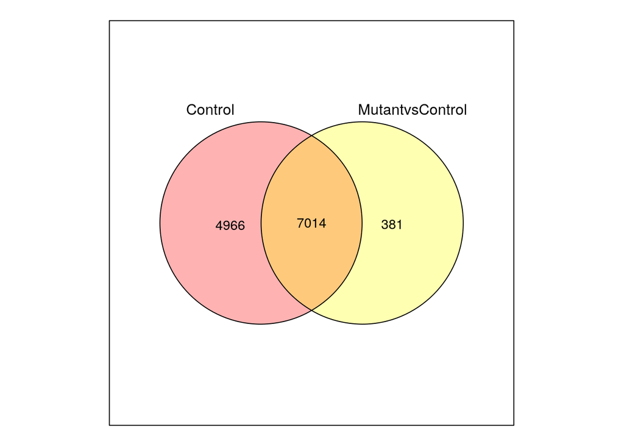

```r
get <- get.siggenes(tstep, vars = "all")
get.groups <- get.siggenes(tstep, vars = "groups")
suma2Venn(get.groups$summary)
```

## 4.6 Clustering of differentially expressed genes

The clustering of differentially expressed is performed with the `see.genes` function, which plots the expression of all genes in each group as well as the expression profiles of each group. There are three available clustering algorithms. In this tutorial, we are using the hierarchical clustering.

```r
out <- see.genes(get$sig.genes, color.mode = "gray", newX11 = FALSE)
```

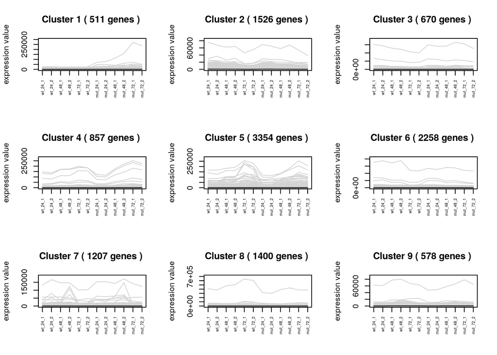

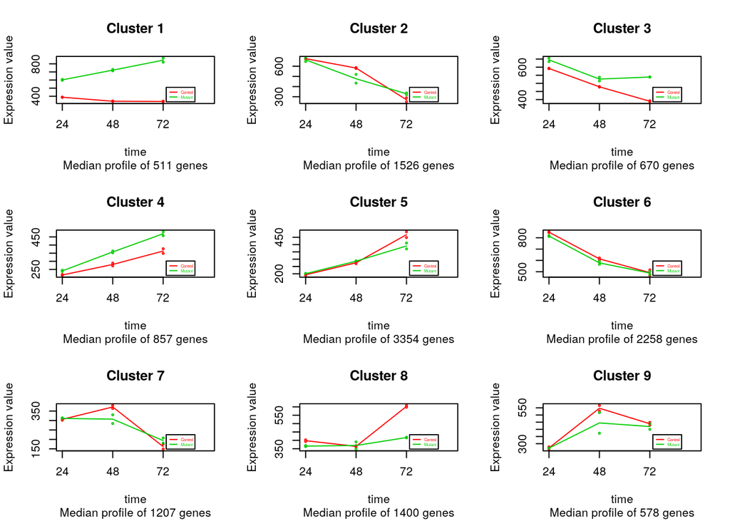

```r
out.groups <- see.genes(get.groups$sig.genes$MutantvsControl, color.mode = "gray",
    newX11 = FALSE)
```

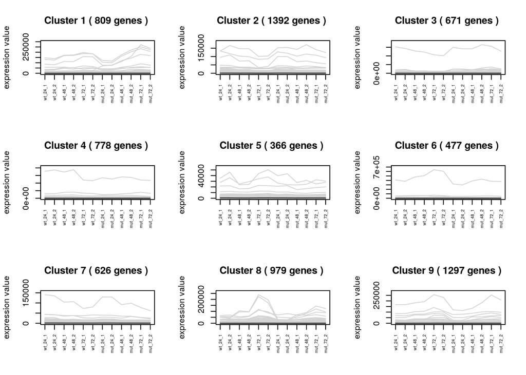

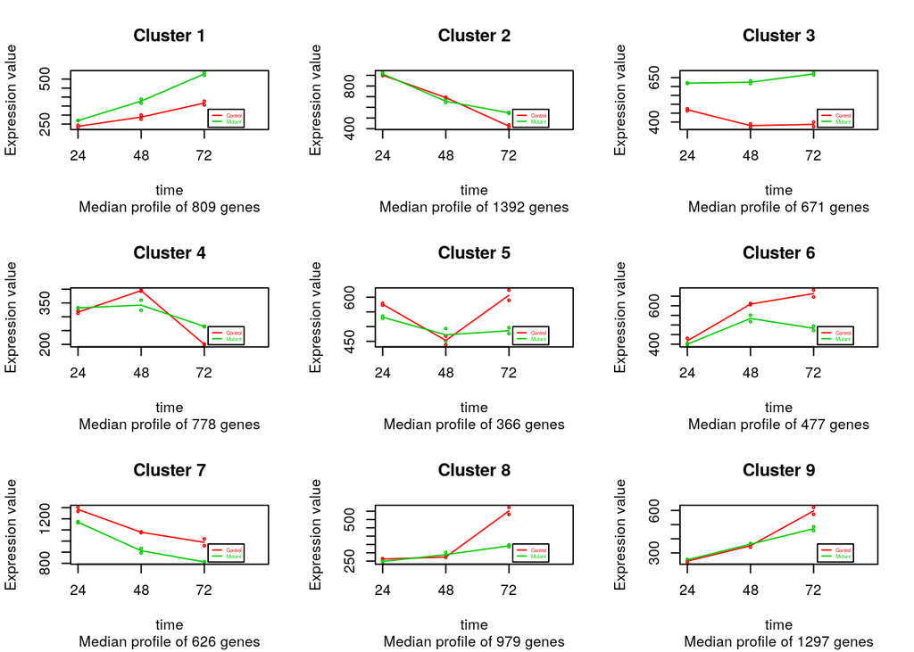

# 5 Functional enrichment analysis

After obtaining the list of differentially expressed genes, we can check in a specified list of genes if some group of genes is overrepresented. For that purpose, we will use the `clusterProfiler` package (Yu et al. 2012), and it’s function `enrichGO`. The function takes the list of genes, organism database and the sub-ontology category as its inputs. Moreover, the user ca specify the identifier type, as well as the significance thresholds (p-value and FDR rate for multiple comparison).

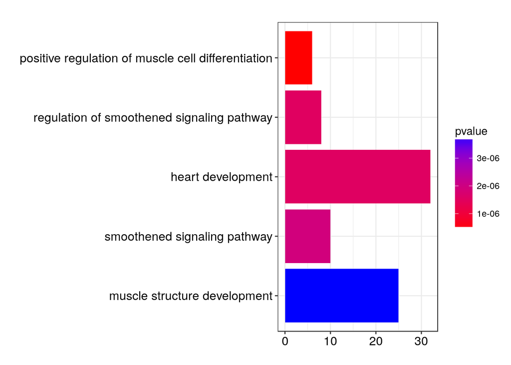

```r
geneList <- sort(names(out$cut[out$cut == 3]), decreasing = TRUE)
ego <- enrichGO(gene = geneList, OrgDb = org.Dr.eg.db, keyType = "ENSEMBL",
    ont = "ALL", pAdjustMethod = "BH", pvalueCutoff = 0.01, qvalueCutoff = 0.05)
barplot(ego)
```

# References

Anders, S., and W. Huber. 2010. “Differential Expression Analysis for Sequence Count Data.” Journal Article. *Genome Biol* 11 (10): R106. doi:10.1186/gb-2010-11-10-r106.

Conesa, A., M. J. Nueda, A. Ferrer, and M. Talon. 2006. “MaSigPro: A Method to Identify Significantly Differential Expression Profiles in Time-Course Microarray Experiments.” Journal Article. *Bioinformatics* 22 (9): 1096–1102. doi:10.1093/bioinformatics/btl056.

Etard, C., O. Armant, U. Roostalu, V. Gourain, M. Ferg, and U. Strahle. 2015. “Loss of Function of Myosin Chaperones Triggers Hsf1-Mediated Transcriptional Response in Skeletal Muscle Cells.” Journal Article. *Genome Biol* 16: 267. doi:10.1186/s13059-015-0825-8.

Love, M. I., W. Huber, and S. Anders. 2014. “Moderated Estimation of Fold Change and Dispersion for Rna-Seq Data with Deseq2.” Journal Article. *Genome Biol* 15 (12): 550. doi:10.1186/s13059-014-0550-8.

Nueda, M. J., S. Tarazona, and A. Conesa. 2014. “Next maSigPro: Updating maSigPro Bioconductor Package for Rna-Seq Time Series.” Journal Article. *Bioinformatics* 30 (18): 2598–2602. doi:10.1093/bioinformatics/btu333.

Yu, G., L. G. Wang, Y. Han, and Q. Y. He. 2012. “ClusterProfiler: An R Package for Comparing Biological Themes Among Gene Clusters.” Journal Article. *OMICS* 16 (5): 284–7. doi:10.1089/omi.2011.0118.